# Data Analysis with R - Titanic

```r
# In this project I am goint to visualize Titanic dataset in R.
```

## Import the Libraries

```r
library(ggplot2) # This library for graphs
library(ggthemes) # This one is for graphs 's themes
library(dplyr)  # This one is for combine train and test datasets
```

## Loading Data

```r
train <- read.csv("train.csv", stringsAsFactors = F)
test  <- read.csv("test.csv", stringsAsFactors = F)
options( warn = -1 )
```

## Combine data sets

bind_rows : Needing to combine datasets with non-matching columns

```r
full_data  <- dplyr::bind_rows(train,test)
```

Details of our dataset

```r
str(full_data)
```

```
'data.frame':   1309 obs. of  12 variables:
 $ PassengerId: int  1 2 3 4 5 6 7 8 9 10 ...
 $ Survived   : int  0 1 1 1 0 0 0 0 1 1 ...
 $ Pclass     : int  3 1 3 1 3 3 1 3 3 2 ...
 $ Name       : chr  "Braund, Mr. Owen Harris" "Cumings, Mrs. John Bradley (Florence Briggs Thayer)" "Heikkinen, Miss. Laina" "Futrelle, Mrs. Jacques Heath (Lily May Peel)" ...
 $ Sex        : chr  "male" "female" "female" "female" ...
 $ Age        : num  22 38 26 35 35 NA 54 2 27 14 ...
 $ SibSp      : int  1 1 0 1 0 0 0 3 0 1 ...
 $ Parch      : int  0 0 0 0 0 0 0 1 2 0 ...
 $ Ticket     : chr  "A/5 21171" "PC 17599" "STON/O2. 3101282" "113803" ...
 $ Fare       : num  7.25 71.28 7.92 53.1 8.05 ...
 $ Cabin      : chr  "" "C85" "" "C123" ...
 $ Embarked   : chr  "S" "C" "S" "S" ...
```

Summary of our columns

```r
summary(full_data)
```

```
  PassengerId      Survived          Pclass          Name               Sex
 Min.   :   1   Min.   :0.0000   Min.   :1.000   Length:1309        Length:1309
 1st Qu.: 328   1st Qu.:0.0000   1st Qu.:2.000   Class :character   Class :character
 Median : 655   Median :0.0000   Median :3.000   Mode  :character   Mode  :character
 Mean   : 655   Mean   :0.3838   Mean   :2.295
 3rd Qu.: 982   3rd Qu.:1.0000   3rd Qu.:3.000
 Max.   :1309   Max.   :1.0000   Max.   :3.000
                NA's   :418
      Age            SibSp            Parch          Ticket               Fare
 Min.   : 0.17   Min.   :0.0000   Min.   :0.000   Length:1309        Min.   :  0.000
 1st Qu.:21.00   1st Qu.:0.0000   1st Qu.:0.000   Class :character   1st Qu.:  7.896
 Median :28.00   Median :0.0000   Median :0.000   Mode  :character   Median : 14.454
 Mean   :29.88   Mean   :0.4989   Mean   :0.385                      Mean   : 33.295
 3rd Qu.:39.00   3rd Qu.:1.0000   3rd Qu.:0.000                      3rd Qu.: 31.275
 Max.   :80.00   Max.   :8.0000   Max.   :9.000                      Max.   :512.329
 NA's   :263                                                         NA's   :1
    Cabin             Embarked
 Length:1309        Length:1309
 Class :character   Class :character
 Mode  :character   Mode  :character
```

## Exploratory Analysis

### Age vs Survived

- Here I am going to compare persons age with if they are survived or not
- The reason for use like this: “full_data[1:891,]”, because I just want to analyze train part

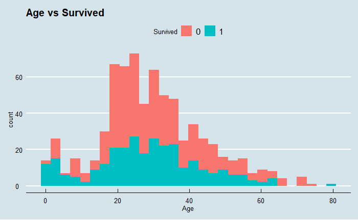

```r
ggplot(full_data[1:891,], aes(Age, fill =factor(Survived))) + # aes= aesthetic mapping
  geom_histogram(bins = 30) +
  theme_economist() +
  xlab("Age") +
  scale_fill_discrete(name = "Survived") +
  ggtitle("Age vs Survived")
```

### Sex vs Survived

Here I am going to compare persons gender with if they are survived or not

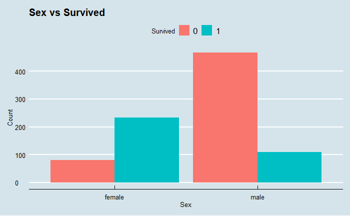

```r
ggplot(full_data[1:891,], aes(Sex, fill = factor(Survived))) +
  geom_bar(stat = "count", position = 'dodge') +
  theme_economist() +
  xlab("Sex") +
  ylab("Count") +
  scale_fill_discrete(name = "Survived") +
  ggtitle("Sex vs Survived")
```

### Age vs Sex vs Survived

Here I am going to compare persons age and gender with if they are survived or not

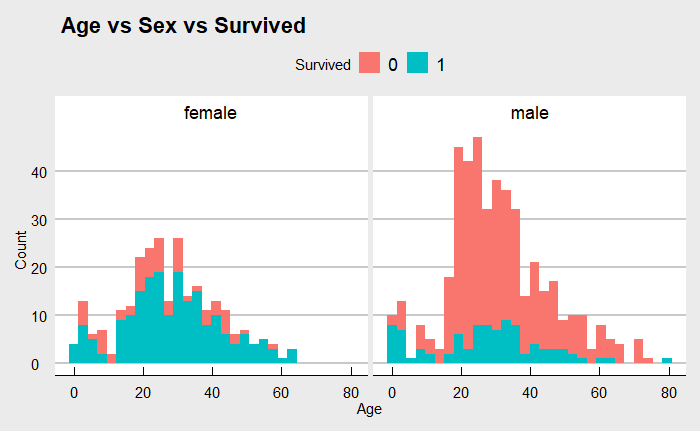

```r
ggplot(full_data[1:891,], aes(Age, fill = factor(Survived))) +
  geom_histogram(bins = 30) +
  theme_economist_white() +
  xlab("Age") +
  ylab("Count") +
  facet_grid(.~Sex) +
  scale_fill_discrete(name = "Survived") +
  ggtitle(" Age vs Sex vs Survived ")
```

### Pclass vs Survived

Here I am going to compare persons platform class with if they are survived or not

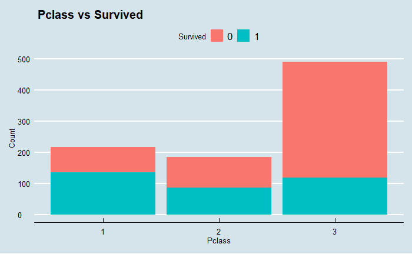

```r
ggplot(full_data[1:891, ], aes(Pclass, fill = factor(Survived))) +
  geom_bar(stat = "count") +
  theme_economist() +
  xlab("Pclass") +
  ylab("Count") +
  scale_fill_discrete(name = "Survived") +
  ggtitle(" Pclass vs Survived")
```

### Pclass vs Sex vs Age vs Survived

Here I am going to compare persons platform class, gender, and age with if they are survived or not

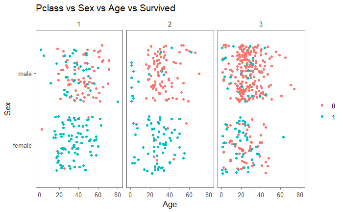

```r
ggplot(full_data[1:891,], aes(x = Age, y = Sex)) +
  geom_jitter(aes(colour = factor(Survived))) +
  theme_few() +
  theme(legend.title = element_blank()) +
  facet_wrap(~Pclass) +
  labs(x = "Age", y="Sex", title = "Pclass vs Sex vs Age vs Survived") +
  scale_fill_discrete(name = "Survived") +
  scale_x_continuous(name = "Age", limits = c(0,81))
```

Here as you can see, names labeled (for instance; Mr, Ms, etc.)

```r
head(as.character(full_data$Name))
```

```
[1] "Braund, Mr. Owen Harris"
[2] "Cumings, Mrs. John Bradley (Florence Briggs Thayer)"
[3] "Heikkinen, Miss. Laina"
[4] "Futrelle, Mrs. Jacques Heath (Lily May Peel)"
[5] "Allen, Mr. William Henry"
[6] "Moran, Mr. James"
```

Now I am going to show them on a table

```r
# Extract titles
full_data$Title <- gsub('(.*, )|(\\..*)', '', full_data$Name)
# Titles by Sex
table(full_data$Sex, full_data$Title)
```

```
         Capt Col Don Dona  Dr Jonkheer Lady Major Master Miss Mlle Mme  Mr Mrs  Ms Rev
  female    0   0   0    1   1        0    1     0      0  260    2   1   0 197   2   0
  male      1   4   1    0   7        1    0     2     61    0    0   0 757   0   0   8

         Sir the Countess
  female   0            1
  male     1            0
```

As you can realize from the table some persons are labeled as Mlle, Mme, etc. Here I am going to replace them with Miss and Mrs. Also I am going to reassign officer and royalty which is used rarely.

```r
# Reassign rare titles
officer <- c('Capt', 'Col', 'Don', 'Dr', 'Major', 'Rev')
royalty <- c('Dona', 'Lady', 'the Countess', 'Sir', 'Jonkheer')
# Reassign Mlle, Ms, Mme and officer, and royalty
full_data$Title[full_data$Title == 'Mlle']    <- 'Miss'
full_data$Title[full_data$Title == 'Ms']      <- 'Miss'
full_data$Title[full_data$Title == 'Mme']     <- 'Mrs'
full_data$Title[full_data$Title %in% royalty]    <- 'Royalty'
full_data$Title[full_data$Title %in% officer]    <- 'Officer'
# Here I am going to seperate Surname from Name
full_data$Surname <- sapply(full_data$Name, function(x) strsplit(x, split = '[,.]')[[1]][1])
```

Here I am going to compare persons title with if they are survived or not

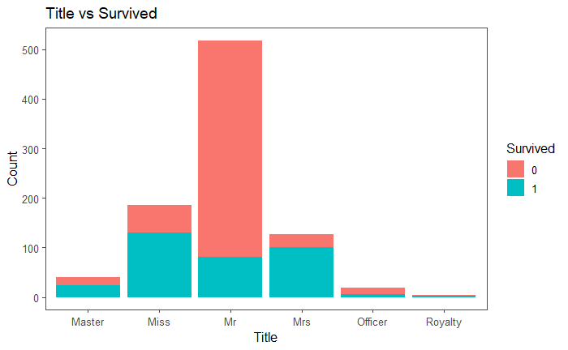

```r
ggplot(full_data[1:891,], aes(Title, fill = factor(Survived))) +
  geom_bar(stat = "count") +
  theme_few() +
  xlab('Title') +
  ylab('Count') +
  scale_fill_discrete(name = "Survived") +
  ggtitle("Title vs Survived")
```